# EDA Project 2 with Plotly

James Eddy

January 6, 2016

```r
knitr::opts_chunk$set(fig.width=7, fig.height=5, fig.align='center',
                      echo=TRUE, warning=FALSE, message=FALSE)
knitr::opts_knit$set(root.dir = "..")
```

### Load required packages

```r
library(dplyr)
library(ggplot2)
library(plotly)
```

### Get & set up data

```r
# Create a directory to store data, if one doesn't already exist
if (!file.exists("data/")) {
    dir.create("data/")
}

# Download the data from the web and record the date and time
if (!file.exists("data/FNEI_data.zip")) {
    fileAddress <- paste0("https://d396qusza40orc.cloudfront.net/",
                          "exdata%2Fdata%2FNEI_data.zip")

    download.file(fileAddress, "data/FNEI_data.zip",
                  method = "curl")
    dateDownloaded <- date()

    file.create("data/dateDownloaded.txt")
    con <- file("data/dateDownloaded.txt")
    writeChar(dateDownloaded, con)
    close(con)
}

# Unzip the data file
if (!file.exists("data/Source_Classification_Code.rds")) {
    unzip(zipfile = "data/FNEI_data.zip", exdir = "data/")
}
```

### Load the data

```r
NEI <- readRDS("data/summarySCC_PM25.rds")
SCC <- readRDS("data/Source_Classification_Code.rds")
```

### Question 1

Have total emissions from PM2.5 decreased in the United States from 1999 to 2008? Using the base plotting system, make a plot showing the total PM2.5 emission from all sources for each of the years 1999, 2002, 2005, and 2008.

```r
# Use dplyr functions to sum the emission across all sources for each year
annualEmissions <- NEI %>%
    group_by(year) %>%
    summarise(num_Observations = length(Emissions),
              Emissions = sum(Emissions))
```

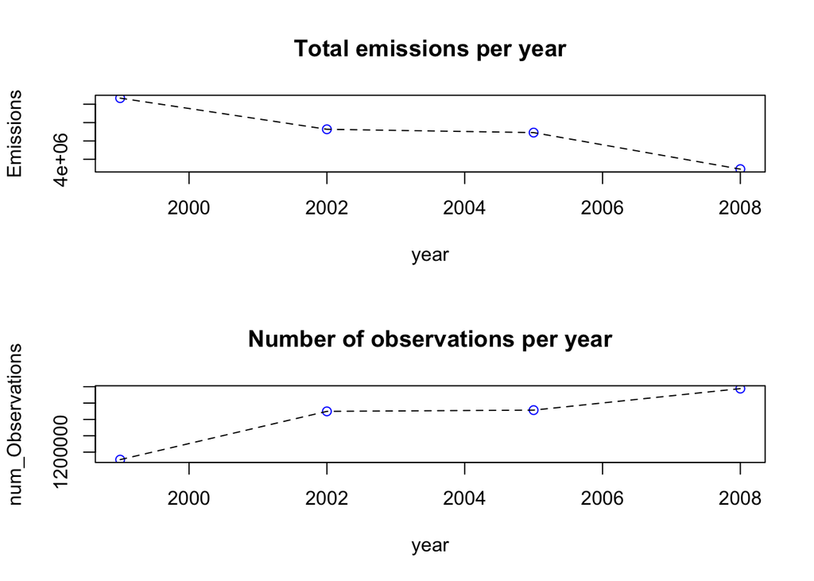

```r
# Create a basic scatter plot of total emissions vs. year, with a dashed line
# showing rough trend over time; also, plot the total number of observations
# for each year
par(mfrow = c(2, 1))
with(annualEmissions, {
    plot(year, Emissions, col = "blue",
         main = "Total emissions per year")
    lines(year, Emissions, lty = 2)
    plot(year, num_Observations, col = "blue",
         main = "Number of observations per year")
    lines(year, num_Observations, lty = 2)
})
```

In spite of the number of observations increasing each year (suggesting greater vigilance in monitoring emissions) from 1999 to 2008, the total emissions have clearly decreased over this time period.

### Question 2

Have total emissions from PM2.5 decreased in the Baltimore City, Maryland (fips == “24510”) from 1999 to 2008? Use the base plotting system to make a plot answering this question.

```r
# Use dplyr functions to sum the emission across all sources for each year,
# this time filtering observations to only include Baltimore based on the
# corresponding fips code
bmoreAnnualEmissions <- NEI %>%
    filter(fips == "24510") %>%
    group_by(year) %>%
    summarise(num_Observations = length(Emissions),
              Emissions = sum(Emissions))
```

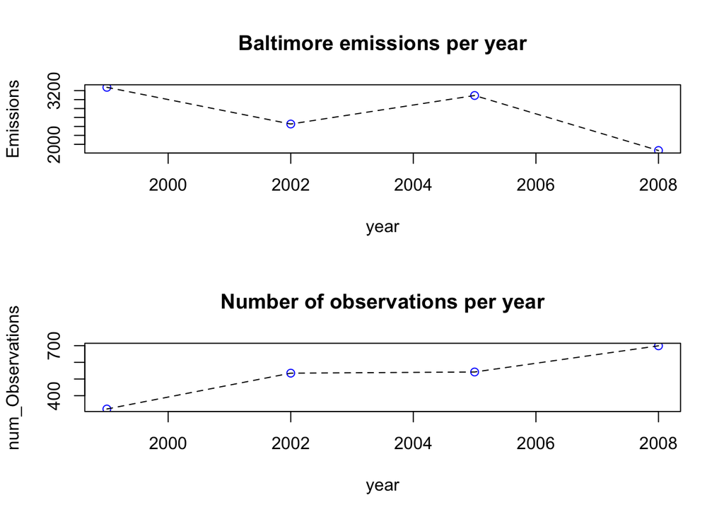

```r
# Create a basic scatter plot of total emissions vs. year, with a dashed line
# showing rough trend over time; also, plot the total number of observations
# for each year
par(mfrow = c(2, 1))
with(bmoreAnnualEmissions, {
    plot(year, Emissions, col = "blue",
         main = "Baltimore emissions per year")
    lines(year, Emissions, lty = 2)
    plot(year, num_Observations, col = "blue",
         main = "Number of observations per year")
    lines(year, num_Observations, lty = 2)
})
```

Again, while the number of source-emissions observations has increased each year from 1999 to 2008, the total emissions have clearly decreased over the full span of this time period. Even though there appears to be an increase in total emissions from 2002 to 2005, the total for 2008 is still less than that of 1999.

### Question 3

Of the four types of sources indicated by the type (point, nonpoint, onroad, nonroad) variable, which of these four sources have seen decreases in emissions from 1999–2008 for Baltimore City? Which have seen increases in emissions from 1999–2008? Use the ggplot2 plotting system to make a plot answer this question.

```r
# First, filter observations to only include Baltimore based on the
# corresponding fips code
bmoreEmissions <- NEI %>%
    filter(fips == "24510")
```

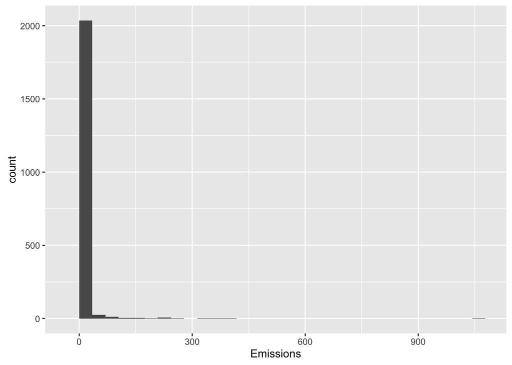

```r
# Plot histogram of emissions values for Baltimore (not included in results)
ggplot(bmoreEmissions, aes(Emissions)) +
    geom_histogram()
```

The histogram shows that the distribution of emissions values is very heavy- tailed, suggesting that it would be useful to log-normalize the data

```r
# Use dplyr to do the following: (1) log-transform emissions values (after
# adding 1 to avoid -Inf values when transforming zeros); (2) calculate the
# total emissions for each year-type combination
bmoreEmissionsSummary <- bmoreEmissions %>%
    mutate(Emissions = log10(Emissions + 1)) %>%
    group_by(year, type) %>%
    mutate(total_Emissions = sum(Emissions))
```

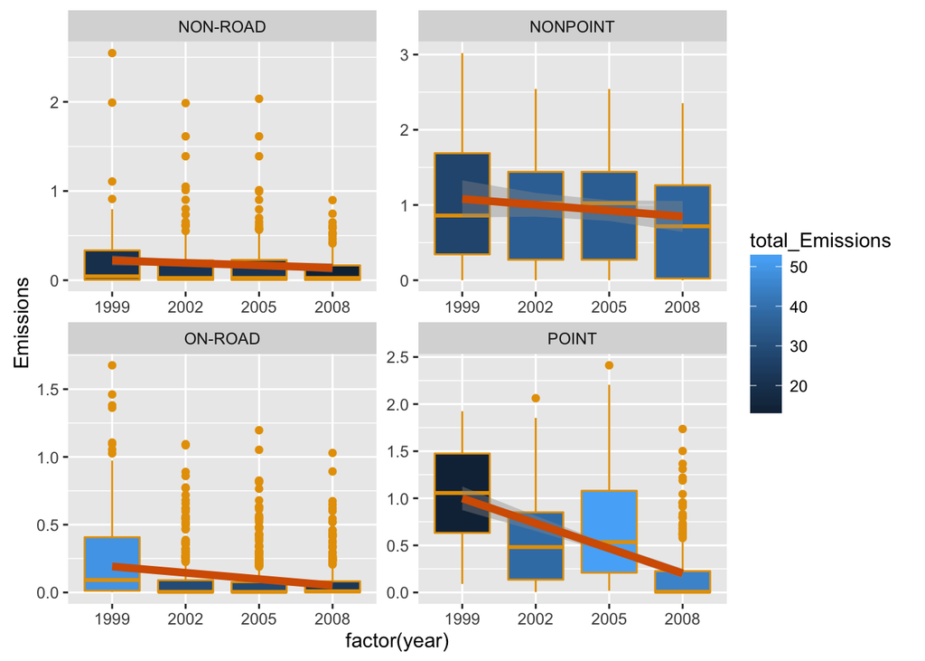

```r
# Create boxplots of the data, showing the median, 75th percentile, and 25th
# percentile for each year; fit a basic linear regression line to
# estimate the trend; show each type of emission in a separate panel; scale the
# fill color of boxes according to the total emissions
ggplot(bmoreEmissionsSummary, aes(factor(year), Emissions)) +
    geom_boxplot(aes(fill = total_Emissions), colour = "#E69F00") +
    geom_smooth(method = "lm", aes(group = 1),
                colour = "#D55E00", size = 2) +
    facet_wrap(~ type, scales = "free")
```

Based on the overall trends (as modeled by linear regression), each source type shows a decrease in emissions from 1999 to 2008. However, based on median emissions, the pattern is less consistent: (1) non-road sources show only a very modest decrease; non-point sources increase in 2002 and 2005 before decreasing in 2008; and point sources decrease, increase, and then decrease again. Based on total emissions, both non-point and point sources also seem to show a relative increase in 2008 compared to 1999. On-road sources are consistently decreased (albeit modestly) from 1999-2008 across all measures.

### Question 4

Across the United States, how have emissions from coal combustion-related sources changed from 1999–2008?

```r
# Use grep to identify all coal sources and subset the SCC table
coalSources <- grep("coal", tolower(SCC$SCC.Level.Three))
coalSCC <- SCC[coalSources, ]

# Use dplyr to do the following: (1) filter observations to only include coal
# sources; (2) log-transform emissions values (after adding 1 to avoid -Inf
# values when transforming zeros); (3) calculate total emissions for each year
coalEmissionsSummary <- NEI %>%
    filter(SCC %in% coalSCC$SCC) %>%
    mutate(Emissions = log10(Emissions + 1)) %>%
    group_by(year) %>%
    mutate(total_Emissions = sum(Emissions))
```

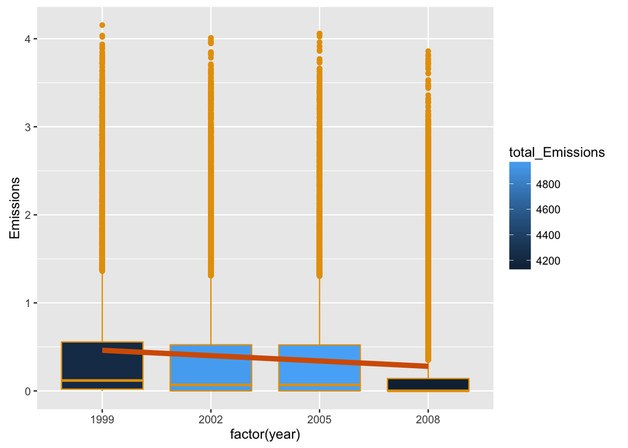

```r
# Create boxplots of the data, showing the median, 75th percentile, and 25th
# percentile for each year; fit a basic linear regression line to estimate the
# trend; scale the fill color of boxes according to the total emissions
ggplot(coalEmissionsSummary, aes(factor(year), Emissions)) +
    geom_boxplot(aes(fill = total_Emissions), colour = "#E69F00") +
    geom_smooth(method = "lm", aes(group = 1),
                colour = "#D55E00", size = 2)
```

Based on the overall trend (as modeled by linear regression), coal sources show a decrease in emissions from 1999 to 2008; this pattern is also reflected by median emissions, which decrease or remain steady each observed year. Based on total emissions, there is an increase for the period of 2002-2008 before decreasing in 2008.

### Question 5

How have emissions from motor vehicle sources changed from 1999–2008 in Baltimore City?

```r
# Use grep to identify all motor vehicle sources, as indicated by the term
# "mobile," and subset the SCC table
mobileSources <- grep("mobile", tolower(SCC$SCC.Level.One))
mobileSCC <- SCC[mobileSources, ]

# Use dplyr to do the following: (1) filter observations to only include mobile
# sources and observations in Baltimore (based on fips code); (2) log-transform
# emissions values (after adding 1 to avoid -Inf values when transforming
# zeros); (3) calculate total emissions for each year
mobileBmoreEmissionsSummary <- NEI %>%
    filter(SCC %in% mobileSCC$SCC, fips == "24510") %>%
    mutate(Emissions = log10(Emissions + 1)) %>%
    group_by(year) %>%
    mutate(total_Emissions = sum(Emissions))
```

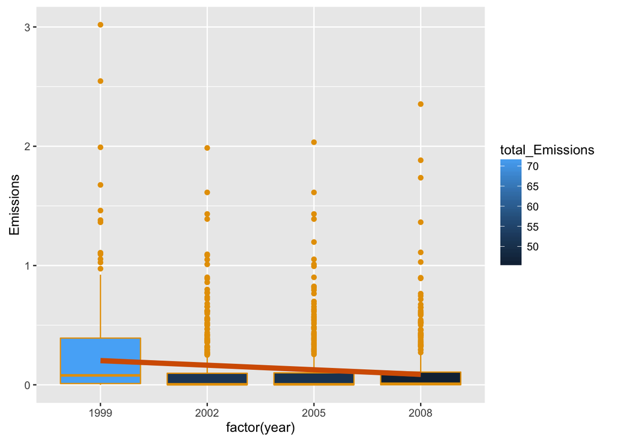

```r
# Create boxplots of the data, showing the median, 75th percentile, and 25th
# percentile for each year; fit a basic linear regression line to estimate the
# trend; scale the fill color of boxes according to the total emissions
ggplot(mobileBmoreEmissionsSummary, aes(factor(year), Emissions)) +
    geom_boxplot(aes(fill = total_Emissions), colour = "#E69F00") +
    geom_smooth(method = "lm", aes(group = 1),
                colour = "#D55E00", size = 2)
```

Based on the overall trend (as modeled by linear regression), motor vehicle sources in Baltimore show a decrease in emissions from 1999 to 2008; this pattern is mostly reflected by median emissions, which decrease or remain steady each observed year. Total emissions also appear to decrease over time from 1999-2008.

### Question 6

Compare emissions from motor vehicle sources in Baltimore City with emissions from motor vehicle sources in Los Angeles County, California (fips == “06037”). Which city has seen greater changes over time in motor vehicle emissions?

```r
# Use grep to identify all motor vehicle sources, as indicated by the term
# "mobile," and subset the SCC table
mobileSources <- grep("mobile", tolower(SCC$SCC.Level.One))
mobileSCC <- SCC[mobileSources, ]

# Use dplyr to do the following: (1) filter observations to only include mobile
# sources and observations in Baltimore and Los Angeles County (based on fips
# code); (2) log-transform emissions values (after adding 1 to avoid -Inf values
# when transforming zeros); (3) calculate total emissions for each year-location
# combination
mobileEmissionsComp <- NEI %>%
    filter(SCC %in% mobileSCC$SCC, fips %in% c("24510", "06037")) %>%
    mutate(Emissions = log10(Emissions + 1)) %>%
    group_by(year, fips) %>%
    mutate(total_Emissions = sum(Emissions))
```

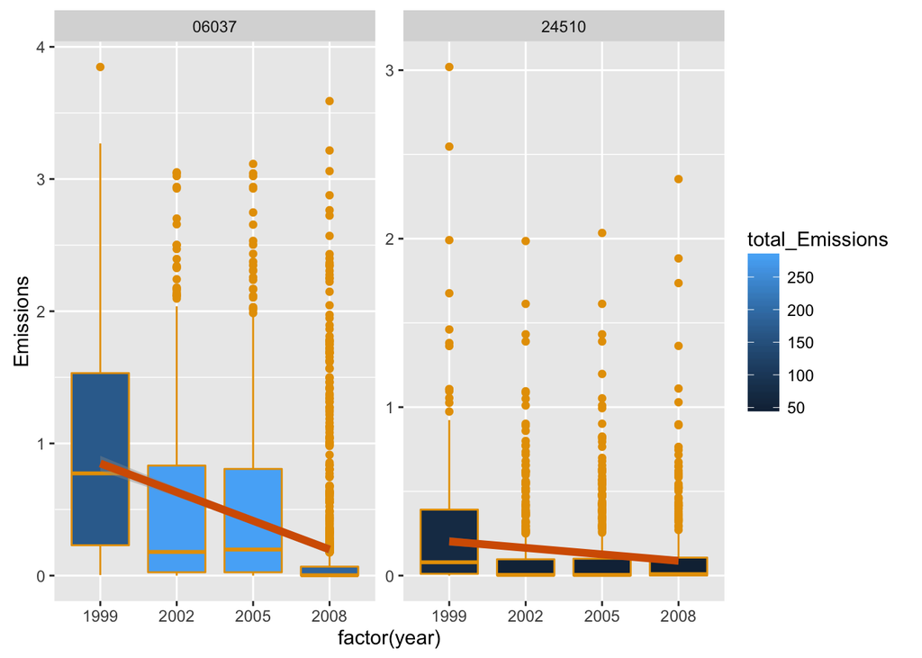

```r
# Create boxplots of the data, showing the median, 75th percentile, and 25th
# percentile for each year; fit a basic linear regression line to estimate the
# trend; show each location in a separate pane; scale the fill color of boxes
# according to the total emissions
ggplot(mobileEmissionsComp, aes(factor(year), Emissions)) +
    geom_boxplot(aes(fill = total_Emissions), colour = "#E69F00") +
    geom_smooth(method = "lm", aes(group = 1),
                colour = "#D55E00", size = 2) +
    facet_wrap(~ fips, scales = "free")
```

Based on the overall trends (as modeled by linear regression), motor vehicle sources show a decrease in emissions from 1999 to 2008 for both Baltimore and Los Angeles County; this pattern is also reflected by median emissions, but more dramatically in Los Angeles, which has much higher emission levels than Baltimore in general. While the percent change in median emissions might be similar for both cities, Los Angeles clearly shows a greater “absolute” decrease from 1999 to 2008. Interestingly, based on total emissions, there is an increase for the period of 2002-2008 in Los Angeles before decreasing in 2008; total emissions in Baltimore are generally decreasing or steady.